# Choice Modeling

## Brief

DB Breweries (DB) with their flagship product, Heineken beer, has been losing market share to the premium beers offered by their main competitor New Zealand Breweries, Stella Artois and Steinlager. As DB currently only has one offering in the premium beer category they are interested in determining the effects of introducing a second premium product to the New Zealand market, Amstel. The aim is to maximise overall market share without negatively impacting the image of the Heineken brand.

They would also like to know how all of these brands affect their non-premium brand Export Gold, other premium brands, as well as other non-premium brands.

Ultimately, DB Breweries would like to determine:

- How do the 4 premium brands (Steinlager, Stella Artois, Heineken and Amstel) react to each other’s prices (these can be offered at ‘special’ discounts of $19.95 and up to a maximum of $25.95)?
- How does the Amstel brand affect the share of one of their more popular (but not premium) brands, DB Export Gold (assume its price can range from $15.95 to $17.95)?
- Does it take share away from other premium beer (assumed to be the fixed price of $19.95)?
- Does it take share away from other ‘mainstream’ beers (assume they are at a fixed price of $15.95)?

## Methodology

### Experimental Design

In order to answer these questions we will use a discrete choice model to determine customer preference for different brands at different price points. In order to gather the required data we present a series of choice sets to a sample of consumers which mimics what they may encounter on a trip to the supermarket or liquor store.

[figure not shown]

One of the 27 choice sets provided.

In an ideal world we would be able to present every possible combination of brands and price point, 243 scenarios, to each individual but due to certain constraints such as time, funding, and survey fatigue we must use the most efficient number of choice sets in order to ascertain the answers that we seek. As such we use the following SAS functions to determine the combinations of brands and price for each set of choices.

```
%MKTRUNS(3 3 3 3 3)

%mktdes(factors=x1-x5=3,n=27)
proc print;
run;
```

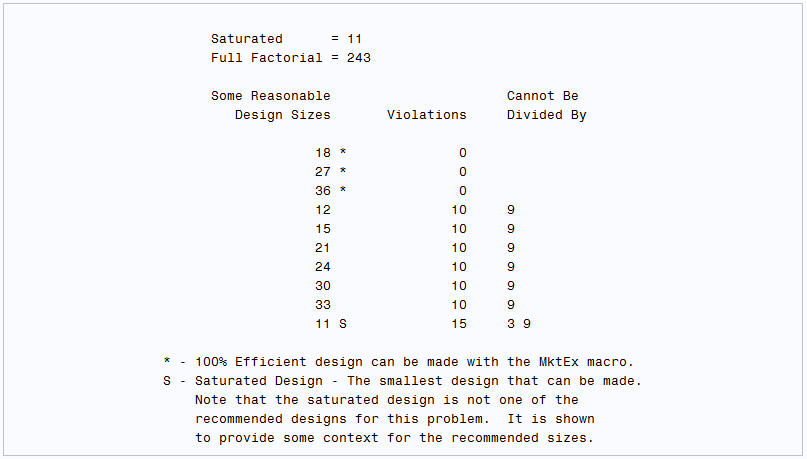

27 choice sets were used as this design has over 99% efficiency with less chance of survey fatigue.

### Pricing Structure

Each of the four premium beers are available to participants at either $19.95, $22.95 and $25.95 while the non-premium Export Gold is listed at either $15.95, $16.95 and $17.95. Other brand premium and non-premium options are kept at $19.95 and $15.95 respectively. By using three price points for each brand we can measure the impact of price sensitivity on comsumer choice as this is unlikely to be a linear relationship.

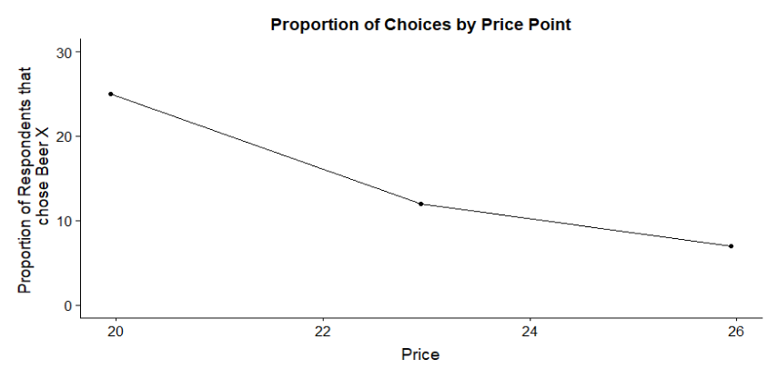

Example: Utility of using three price points to model price sensitivity

### Who We Talked To

As the target market of Amstel is premium beer drinkers it made sense to compose our panel with people that identify as such. These individuals are likely less price sensitive than the general beer drinking population and are a ever-growing segment of the local beer market.

### Terms of Interest

We are interested in the direct effect of price on the likelihood of a consumer choosing a particular brand as well as the second order effect, the impact of the price of one brand impacting the likelihood of a consumer choosing another brand. While the impact on market share of price interactions between the brands under investigation is one of the main objectives, interaction terms involving Export Gold and Steinlager were removed in order to reduce multicollinearity and provide more accurate estimates for the remaining interaction terms. The justification was that Export Gold is not a premium beer brand and the Steinlager brand is languishing.

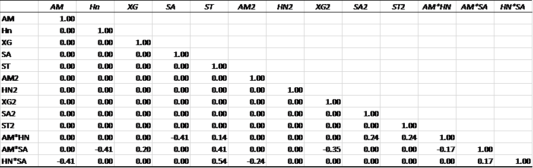

Multicollinearity of terms used in final model.

## Results

### Pricing Scenarios

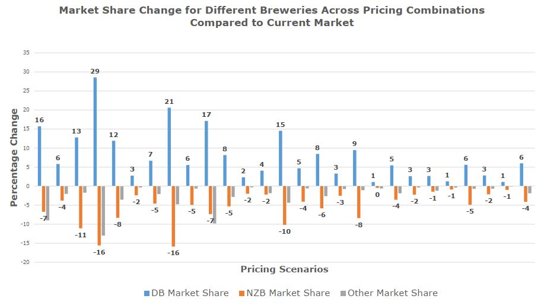

### Interactions We Found

We found that the price of Stella Artois impacted the market share of Amstel meaning that if the price of Stella Artois was higher, consumers were more likely to choose Amstel.